# AYESH_Lab_7

### Lab 7- RNN

### Ayesh Madushanka Mahamada Kalapuwage

```python
import numpy as np
import pandas as pd
from tensorflow.keras.datasets import imdb
from tensorflow.keras.preprocessing import sequence
import os
os.environ['KMP_DUPLICATE_LIB_OK']='True'
from sklearn import datasets, metrics
from sklearn.model_selection import train_test_split
from tensorflow.keras.layers import LSTM, GRU
from tensorflow.keras.optimizers import Adam
from tensorflow.keras.optimizers.schedules import ExponentialDecay
from tensorflow.keras.models import Sequential, Model
from tensorflow.keras.layers import Dense, Input, SimpleRNN
from tensorflow.keras.layers import Embedding
```

#### Q1-Define and prepare your class variables. Use proper variable representations (int, float, one-hot, etc.). Use pre-processing methods (as needed). Describe the final dataset that is used for classification/regression (include a description of any newly formed variables you created). Discuss methods of tokenization in your dataset as well as any decisions to force a specific length of sequence.

Quora insincere Questions Classification dataset. This is a text dataset. Quora is a platform that empowers people to learn from each other. On Quora, people can ask questions and connect with others who contribute unique insights and quality answers but some people use this flatfoam to ask toxic and divisive content. So quora wants to tackele these contents and remove them automatically from the website. This is binary type of problem. 1 is taken as insincere and 0 is taken as sincere contents.

This is very large dataset taht includes 1.3 Million data points. First I tried to run whole dataset but every time after 3-4 hour my Kernek was restarted because of my laptop coudn't support this type of large RNN model. So I had to reduce the data into effortable amount. I took 20000 data points and which include exactly same 1 and 0 contents. I removed "qid" column because it's just identification. Below I mentioned the datatypes of my final dataframe.

Tokenization is a way of separating a piece of text into smaller units called tokens. Here, I have little midium size texts so I kept the max artical length as 1000 because it covers all the words in each contents. Tokenization gives the specific integer for each word and then sequence makes sentence as correct order. Finally pad sequences add the zeros for short sentences to make the all the contents as same length. I didn't use special options and use the default parameters because I just need to identify the toxic and divisive words in the content.

```python
df = pd.read_csv('train.csv')
```

```python
df
```

|  | qid | question_text | target |
| --- | --- | --- | --- |
| 0 | 00002165364db923c7e6 | How did Quebec nationalists see their province... | 0 |
| 1 | 000032939017120e6e44 | Do you have an adopted dog, how would you enco... | 0 |
| 2 | 0000412ca6e4628ce2cf | Why does velocity affect time? Does velocity a... | 0 |
| 3 | 000042bf85aa498cd78e | How did Otto von Guericke used the Magdeburg h... | 0 |
| 4 | 0000455dfa3e01eae3af | Can I convert montra helicon D to a mountain b... | 0 |
| ... | ... | ... | ... |
| 1306117 | ffffcc4e2331aaf1e41e | What other technical skills do you need as a c... | 0 |
| 1306118 | ffffd431801e5a2f4861 | Does MS in ECE have good job prospects in USA ... | 0 |
| 1306119 | ffffd48fb36b63db010c | Is foam insulation toxic? | 0 |
| 1306120 | ffffec519fa37cf60c78 | How can one start a research project based on ... | 0 |
| 1306121 | ffffed09fedb5088744a | Who wins in a battle between a Wolverine and a... | 0 |

1306122 rows × 3 columns

```python
df.info()
```

```
<class 'pandas.core.frame.DataFrame'>
RangeIndex: 1306122 entries, 0 to 1306121
Data columns (total 3 columns):
 #   Column         Non-Null Count    Dtype
---  ------         --------------    -----
 0   qid            1306122 non-null  object
 1   question_text  1306122 non-null  object
 2   target         1306122 non-null  int64
dtypes: int64(1), object(2)
memory usage: 29.9+ MB
```

```python
df['target'].value_counts()
```

```
0    1225312
1      80810
Name: target, dtype: int64
```

```python
df1 = df.loc[df['target']==1, ['question_text','target']]
df1 = df1[:10000]
df2 = df.loc[df['target']==0, ['question_text','target']]
df2 = df2[:10000]
df_final=pd.concat([df1,df2])
```

```python
df_final.info()
```

```
<class 'pandas.core.frame.DataFrame'>
Int64Index: 20000 entries, 22 to 10667
Data columns (total 2 columns):
 #   Column         Non-Null Count  Dtype
---  ------         --------------  -----
 0   question_text  20000 non-null  object
 1   target         20000 non-null  int64
dtypes: int64(1), object(1)
memory usage: 468.8+ KB
```

```python
y=df_final.target.to_numpy()
X=df_final.question_text.to_numpy()
```

```python
%%time
from tensorflow import keras
from tensorflow.keras.preprocessing.text import Tokenizer
from tensorflow.keras.preprocessing.sequence import pad_sequences

NUM_TOP_WORDS = None # use entire vocabulary!
MAX_ART_LEN = 1000 # maximum and minimum number of words

#tokenize the text
tokenizer = Tokenizer(num_words=NUM_TOP_WORDS)
tokenizer.fit_on_texts(df_final.question_text)
# save as sequences with integers replacing words
sequences = tokenizer.texts_to_sequences(df_final.question_text)

word_index = tokenizer.word_index
NUM_TOP_WORDS = len(word_index) if NUM_TOP_WORDS==None else NUM_TOP_WORDS
top_words = min((len(word_index),NUM_TOP_WORDS))
print('Found %s unique tokens. Distilled to %d top words.' % (len(word_index),top_words))

X = pad_sequences(sequences, maxlen=MAX_ART_LEN)

#y_ohe = keras.utils.to_categorical(bunch.target)
print('Shape of data tensor:', X.shape)
print('Shape of label tensor:', y.shape)
print(np.max(X))
```

```
Found 23404 unique tokens. Distilled to 23404 top words.
Shape of data tensor: (20000, 1000)
Shape of label tensor: (20000,)
23404
CPU times: user 804 ms, sys: 31.5 ms, total: 836 ms
Wall time: 836 ms
```

#### Q3-Choose the method you will use for dividing your data into training and testing (i.e., are you using Stratified 10-fold cross validation? Shuffle splits? Why?). Explain why your chosen method is appropriate or use more than one method as appropriate. Convince me that your train/test splitting method is a realistic mirroring of how an algorithm would be used in practice.

I have nearly same 10000 amount of images for each class. During the each round Kfold uses one fold as test and the remaining 9 as training. However, in shufflesplit, during each round n it will only use training and testing set from iteration n. When the datset bigger and bigger, cross validation time also increases, making the shuffle split a more attactive method. I choose Shuffle split.

It allows the training converge fast, prevents bias during the training and prevents the model from learning the order of the training. I have reduced my dataset size to 20000. So I can use some repeated shuffling.

```python
X_train, X_test, y_train, y_test = train_test_split(X, y, test_size=0.2, stratify=df_final.target,random_state=42)

X_train.shape
```

```
(16000, 1000)
```

```python
X_test.shape
```

```
(4000, 1000)
```

```python
!head "glove.6B.50d.txt"
```

```
the 0.418 0.24968 -0.41242 0.1217 0.34527 -0.044457 -0.49688 -0.17862 -0.00066023 -0.6566 0.27843 -0.14767 -0.55677 0.14658 -0.0095095 0.011658 0.10204 -0.12792 -0.8443 -0.12181 -0.016801 -0.33279 -0.1552 -0.23131 -0.19181 -1.8823 -0.76746 0.099051 -0.42125 -0.19526 4.0071 -0.18594 -0.52287 -0.31681…
, 0.013441 0.23682 -0.16899 0.40951 0.63812 0.47709 -0.42852 -0.55641 -0.364 -0.23938 0.13001 -0.063734 -0.39575 -0.48162 0.23291 0.090201 -0.13324 0.078639 -0.41634 -0.15428 0.10068 0.48891 0.31226 -0.1252 -0.037512 -1.5179 0.12612 -0.02442 -0.042961 -0.28351 3.5416 -0.11956 -0.014533 -0.1499 0.218…
. 0.15164 0.30177 -0.16763 0.17684 0.31719 0.33973 -0.43478 -0.31086 -0.44999 -0.29486 0.16608 0.11963 -0.41328 -0.42353 0.59868 0.28825 -0.11547 -0.041848 -0.67989 -0.25063 0.18472 0.086876 0.46582 0.015035 0.043474 -1.4671 -0.30384 -0.023441 0.30589 -0.21785 3.746 0.0042284 -0.18436 -0.46209 0.098…
of 0.70853 0.57088 -0.4716 0.18048 0.54449 0.72603 0.18157 -0.52393 0.10381 -0.17566 0.078852 -0.36216 -0.11829 -0.83336 0.11917 -0.16605 0.061555 -0.012719 -0.56623 0.013616 0.22851 -0.14396 -0.067549 -0.38157 -0.23698 -1.7037 -0.86692 -0.26704 -0.2589 0.1767 3.8676 -0.1613 -0.13273 -0.68881 0.1844…
to 0.68047 -0.039263 0.30186 -0.17792 0.42962 0.032246 -0.41376 0.13228 -0.29847 -0.085253 0.17118 0.22419 -0.10046 -0.43653 0.33418 0.67846 0.057204 -0.34448 -0.42785 -0.43275 0.55963 0.10032 0.18677 -0.26854 0.037334 -2.0932 0.22171 -0.39868 0.20912 -0.55725 3.8826 0.47466 -0.95658 -0.37788 0.2086…
and 0.26818 0.14346 -0.27877 0.016257 0.11384 0.69923 -0.51332 -0.47368 -0.33075 -0.13834 0.2702 0.30938 -0.45012 -0.4127 -0.09932 0.038085 0.029749 0.10076 -0.25058 -0.51818 0.34558 0.44922 0.48791 -0.080866 -0.10121 -1.3777 -0.10866 -0.23201 0.012839 -0.46508 3.8463 0.31362 0.13643 -0.52244 0.3302…
in 0.33042 0.24995 -0.60874 0.10923 0.036372 0.151 -0.55083 -0.074239 -0.092307 -0.32821 0.09598 -0.82269 -0.36717 -0.67009 0.42909 0.016496 -0.23573 0.12864 -1.0953 0.43334 0.57067 -0.1036 0.20422 0.078308 -0.42795 -1.7984 -0.27865 0.11954 -0.12689 0.031744 3.8631 -0.17786 -0.082434 -0.62698 0.2649…
a 0.21705 0.46515 -0.46757 0.10082 1.0135 0.74845 -0.53104 -0.26256 0.16812 0.13182 -0.24909 -0.44185 -0.21739 0.51004 0.13448 -0.43141 -0.03123 0.20674 -0.78138 -0.20148 -0.097401 0.16088 -0.61836 -0.18504 -0.12461 -2.2526 -0.22321 0.5043 0.32257 0.15313 3.9636 -0.71365 -0.67012 0.28388 0.21738 0.1…
" 0.25769 0.45629 -0.76974 -0.37679 0.59272 -0.063527 0.20545 -0.57385 -0.29009 -0.13662 0.32728 1.4719 -0.73681 -0.12036 0.71354 -0.46098 0.65248 0.48887 -0.51558 0.039951 -0.34307 -0.014087 0.86488 0.3546 0.7999 -1.4995 -1.8153 0.41128 0.23921 -0.43139 3.6623 -0.79834 -0.54538 0.16943 -0.82017 -0.…
's 0.23727 0.40478 -0.20547 0.58805 0.65533 0.32867 -0.81964 -0.23236 0.27428 0.24265 0.054992 0.16296 -1.2555 -0.086437 0.44536 0.096561 -0.16519 0.058378 -0.38598 0.086977 0.0033869 0.55095 -0.77697 -0.62096 0.092948 -2.5685 -0.67739 0.10151 -0.48643 -0.057805 3.1859 -0.017554 -0.16138 0.055486 -0…
```

```python
%%time
EMBED_SIZE = 50
# the embed size should match the file you load glove from
embeddings_index = {}
f = open('glove.6B.50d.txt')
# save key/array pairs of the embeddings
#  the key of the dictionary is the word, the array is the embedding
for line in f:
    values = line.split()
    word = values[0]
    coefs = np.asarray(values[1:], dtype='float32')
    embeddings_index[word] = coefs
f.close()

print('Found %s word vectors.' % len(embeddings_index))

# now fill in the matrix, using the ordering from the
#  keras word tokenizer from before
found_words = 0
embedding_matrix = np.zeros((len(word_index) + 1, EMBED_SIZE))
for word, i in word_index.items():
    embedding_vector = embeddings_index.get(word)
    if embedding_vector is not None:
        # words not found in embedding index will be ALL-ZEROS
        embedding_matrix[i] = embedding_vector
        found_words = found_words+1

print("Embedding Shape:",embedding_matrix.shape, "\n",
      "Total words found:",found_words, "\n",
      "Percentage:",100*found_words/embedding_matrix.shape[0])
```

```
Found 400000 word vectors.
Embedding Shape: (23405, 50)
 Total words found: 20197
 Percentage: 86.29352702414015
CPU times: user 5.58 s, sys: 153 ms, total: 5.73 s
Wall time: 5.74 s
```

```python
NUM_CLASSES=1
```

```python
from tensorflow.keras.layers import Embedding

# save this embedding now
embedding_layer = Embedding(len(word_index) + 1,
                            EMBED_SIZE,
                            weights=[embedding_matrix],# here is the embedding getting saved
                            input_length=MAX_ART_LEN,
                            trainable=False)
```

#### Q4-Investigate at least two different recurrent network architectures (perhaps LSTM and GRU). Be sure to use an embedding layer (pre-trained, from scratch, OR both). Adjust hyper-parameters of the networks as needed to improve generalization performance (train a total of at least four models). Discuss the performance of each network and compare them.

## LSTM

```python
from tensorflow.keras.layers import LSTM, GRU
from tensorflow.keras.models import Sequential
from tensorflow.keras.optimizers import Adam
from tensorflow.keras.optimizers.schedules import ExponentialDecay

opt = Adam(lr=0.0001, epsilon=0.0001, clipnorm=1.0)

lstm = Sequential()
lstm.add(embedding_layer)
lstm.add(LSTM(100,dropout=0.2, recurrent_dropout=0.2))
lstm.add(Dense(NUM_CLASSES, activation='sigmoid'))
lstm.compile(loss='binary_crossentropy',
              optimizer= opt,
              metrics=['accuracy'])
print(lstm.summary())
```

[output not shown]

```python
history = []
tmp = lstm.fit(X_train, y_train, validation_data=(X_test, y_test), epochs=10, batch_size=64)
history.append( tmp )
```

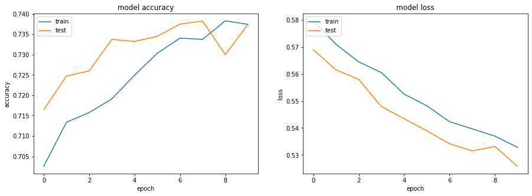

```python
import matplotlib.pyplot as plt


# combine all the history from training together
combined = dict()
for key in ['accuracy','val_accuracy','loss','val_loss']:
    combined[key] = np.hstack([x.history[key] for x in history])

# summarize history for accuracy
plt.figure(figsize=(15,5))
plt.subplot(121)
plt.plot(combined['accuracy'])
plt.plot(combined['val_accuracy'])
plt.title('model accuracy')
plt.ylabel('accuracy')
plt.xlabel('epoch')
plt.legend(['train', 'test'], loc='upper left')

# summarize history for loss
plt.subplot(122)
plt.plot(combined['loss'])
plt.plot(combined['val_loss'])
plt.title('model loss')
plt.ylabel('loss')
plt.xlabel('epoch')
plt.legend(['train', 'test'], loc='upper left')
plt.show()
```

## LSTM2 (RMSprop optimizer + 0.3 dropouts)

```python
from tensorflow.keras.optimizers import RMSprop
opt = RMSprop(lr=0.0001, epsilon=0.0001, clipnorm=1.0)

lstm2 = Sequential()
lstm2.add(embedding_layer)
lstm2.add(LSTM(100,dropout=0.3, recurrent_dropout=0.3))
lstm2.add(Dense(NUM_CLASSES, activation='sigmoid'))
lstm2.compile(loss='binary_crossentropy',
              optimizer= opt,
              metrics=['accuracy'])
print(lstm2.summary())
```

```
Model: "sequential_5"
_________________________________________________________________
Layer (type)                 Output Shape              Param #
=================================================================
embedding_3 (Embedding)      (None, 1000, 50)          1170250
_________________________________________________________________
lstm_5 (LSTM)                (None, 100)               60400
_________________________________________________________________
dense_3 (Dense)              (None, 1)                 101
=================================================================
Total params: 1,230,751
Trainable params: 60,501
Non-trainable params: 1,170,250
_________________________________________________________________
None
```

```python
history = []
tmp1 = lstm2.fit(X_train, y_train, validation_data=(X_test, y_test), epochs=7, batch_size=64)
history.append( tmp1 )
```

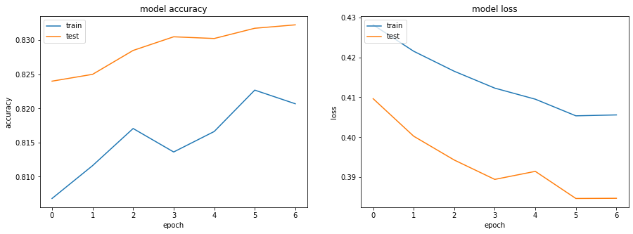

```python
# combine all the history from training together
combined = dict()
for key in ['accuracy','val_accuracy','loss','val_loss']:
    combined[key] = np.hstack([x.history[key] for x in history])

# summarize history for accuracy
plt.figure(figsize=(15,5))
plt.subplot(121)
plt.plot(combined['accuracy'])
plt.plot(combined['val_accuracy'])
plt.title('model accuracy')
plt.ylabel('accuracy')
plt.xlabel('epoch')
plt.legend(['train', 'test'], loc='upper left')

# summarize history for loss
plt.subplot(122)
plt.plot(combined['loss'])
plt.plot(combined['val_loss'])
plt.title('model loss')
plt.ylabel('loss')
plt.xlabel('epoch')
plt.legend(['train', 'test'], loc='upper left')
plt.show()
```

## GRU

```python
opt = Adam(lr=0.0001, epsilon=0.0001, clipnorm=1.0)

gru = Sequential()
gru.add(embedding_layer)
gru.add(GRU(50,dropout=0.2, recurrent_dropout=0.2))
gru.add(Dense(NUM_CLASSES, activation='sigmoid'))
gru.compile(loss='binary_crossentropy',
              optimizer= opt,
              metrics=['accuracy'])
print(gru.summary())
```

```
Model: "sequential_6"
_________________________________________________________________
Layer (type)                 Output Shape              Param #
=================================================================
embedding_3 (Embedding)      (None, 1000, 50)          1170250
_________________________________________________________________
gru (GRU)                    (None, 50)                15300
_________________________________________________________________
dense_4 (Dense)              (None, 1)                 51
=================================================================
Total params: 1,185,601
Trainable params: 15,351
Non-trainable params: 1,170,250
_________________________________________________________________
None
```

```python
history = []
tmp2 = gru.fit(X_train, y_train, validation_data=(X_test, y_test), epochs=3, batch_size=64)
history.append( tmp2)
```

```python
history = []
tmp2 = gru.fit(X_train, y_train, validation_data=(X_test, y_test), epochs=7, batch_size=64)
history.append( tmp2)
```

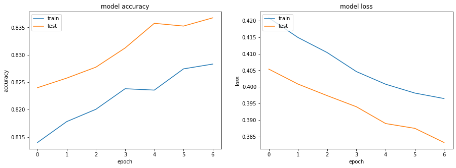

```python
# combine all the history from training together
combined = dict()
for key in ['accuracy','val_accuracy','loss','val_loss']:
    combined[key] = np.hstack([x.history[key] for x in history])

# summarize history for accuracy
plt.figure(figsize=(15,5))
plt.subplot(121)
plt.plot(combined['accuracy'])
plt.plot(combined['val_accuracy'])
plt.title('model accuracy')
plt.ylabel('accuracy')
plt.xlabel('epoch')
plt.legend(['train', 'test'], loc='upper left')

# summarize history for loss
plt.subplot(122)
plt.plot(combined['loss'])
plt.plot(combined['val_loss'])

plt.title('model loss')
plt.ylabel('loss')
plt.xlabel('epoch')
plt.legend(['train', 'test'], loc='upper left')
plt.show()
```

## GRU2 (RMSprop optimizer + 0.3 dropouts + 50 gru network + 0.001 learning rate + 5 extra epochs)

```python
opt = RMSprop(lr=0.001, epsilon=0.0001, clipnorm=1.0)

gru2 = Sequential()
gru2.add(embedding_layer)
gru2.add(GRU(50,dropout=0.3, recurrent_dropout=0.3))
gru2.add(Dense(NUM_CLASSES, activation='sigmoid'))
gru2.compile(loss='binary_crossentropy',
              optimizer= opt,
              metrics=['accuracy'])
print(gru2.summary())
```

```
Model: "sequential_7"
_________________________________________________________________
Layer (type)                 Output Shape              Param #
=================================================================
embedding_3 (Embedding)      (None, 1000, 50)          1170250
_________________________________________________________________
gru_1 (GRU)                  (None, 50)                15300
_________________________________________________________________
dense_5 (Dense)              (None, 1)                 51
=================================================================
Total params: 1,185,601
Trainable params: 15,351
Non-trainable params: 1,170,250
_________________________________________________________________
None
```

```python
history = []
tmp3 = gru2.fit(X_train, y_train, validation_data=(X_test, y_test), epochs=3, batch_size=64)
history.append( tmp3)
```

```python
history = []
tmp3 = gru2.fit(X_train, y_train, validation_data=(X_test, y_test), epochs=7, batch_size=64)
history.append( tmp3)
```

```python
history = []
tmp3 = gru2.fit(X_train, y_train, validation_data=(X_test, y_test), epochs=5, batch_size=64)
history.append( tmp3)
```

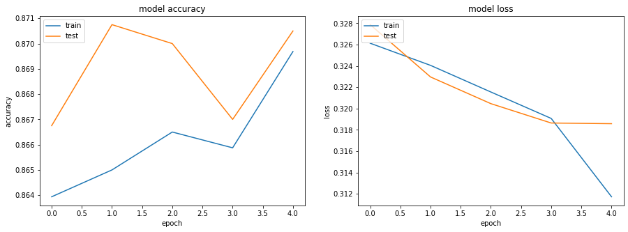

```python
# combine all the history from training together
combined = dict()
for key in ['accuracy','val_accuracy','loss','val_loss']:
    combined[key] = np.hstack([x.history[key] for x in history])

# summarize history for accuracy
plt.figure(figsize=(15,5))
plt.subplot(121)
plt.plot(combined['accuracy'])
plt.plot(combined['val_accuracy'])
plt.title('model accuracy')
plt.ylabel('accuracy')
plt.xlabel('epoch')
plt.legend(['train', 'test'], loc='upper left')

# summarize history for loss
plt.subplot(122)
plt.plot(combined['loss'])
plt.plot(combined['val_loss'])
plt.title('model loss')
plt.ylabel('loss')
plt.xlabel('epoch')
plt.legend(['train', 'test'], loc='upper left')
plt.show()
```

First model is the LSTM one we discussed in the class, I got nearly 73% training and validation accuracy and after 10 epochs the model accuracy and loss graphs mentioned that model doesn't converge yet. I need to run more epochs but the last 2-3 epochs loss was nearly same.

Third model is the GRU one we discussed in the class, I got nearly 83% training and validation accuracy withing 10 epochs and the model accuracy and loss graphs mentioned that model doesn't converged yet. I need to run more epochs.

If I have enought computer capacity, I can use the complete data set for training and it will significantly increase the accuracy of the model.

#### Q5-Using the best RNN parameters and architecture, add a second recurrent chain to your RNN. The input to the second chain should be the output sequence of the first chain. Visualize the performance of training and validation sets versus the training iterations.

```python
opt = RMSprop(lr=0.001, epsilon=0.0001, clipnorm=1.0)

combine = Sequential()
combine.add(embedding_layer)
combine.add(GRU(50,dropout=0.3, recurrent_dropout=0.3,return_sequences=True))
combine.add(GRU(50,dropout=0.2, recurrent_dropout=0.2))
combine.add(Dense(NUM_CLASSES, activation='sigmoid'))
combine.compile(loss='binary_crossentropy',
              optimizer= opt,
              metrics=['accuracy'])
print(combine.summary())
```

```
Model: "sequential_8"
_________________________________________________________________
Layer (type)                 Output Shape              Param #
=================================================================
embedding_3 (Embedding)      (None, 1000, 50)          1170250
_________________________________________________________________
gru_2 (GRU)                  (None, 1000, 50)          15300
_________________________________________________________________
gru_3 (GRU)                  (None, 50)                15300
_________________________________________________________________
dense_6 (Dense)              (None, 1)                 51
=================================================================
Total params: 1,200,901
Trainable params: 30,651
Non-trainable params: 1,170,250
_________________________________________________________________
None
```

```python
history = []
tmp4 = combine.fit(X_train, y_train, validation_data=(X_test, y_test), epochs=3, batch_size=64)
history.append( tmp4)
```

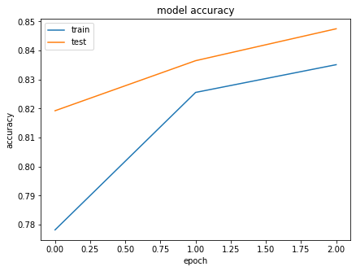

```python
# combine all the history from training together
combined = dict()
for key in ['accuracy','val_accuracy','loss','val_loss']:
    combined[key] = np.hstack([x.history[key] for x in history])

# summarize history for accuracy
plt.figure(figsize=(15,5))
plt.subplot(121)
plt.plot(combined['accuracy'])
plt.plot(combined['val_accuracy'])
plt.title('model accuracy')
plt.ylabel('accuracy')
plt.xlabel('epoch')
plt.legend(['train', 'test'], loc='upper left')
```

#### Q6-Use the method of train/test splitting and evaluation criteria that you argued for at the beginning of the lab. Visualize the results of all the RNNs you trained. Use proper statistical comparison techniques to determine which method(s) is (are) superior.

```python
yhat_lstm = lstm.predict(X_test)
yhat_lstm2 = lstm2.predict(X_test)
yhat_gru = gru.predict(X_test)
yhat_gru2 = gru2.predict(X_test)
```

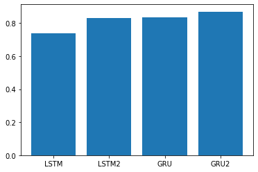

```python
from sklearn import metrics as mt
from matplotlib import pyplot as plt
%matplotlib inline

acc = [mt.accuracy_score(y_test,np.round(yhat_lstm)),
       mt.accuracy_score(y_test,np.round(yhat_lstm2)),
       mt.accuracy_score(y_test,np.round(yhat_gru)),
       mt.accuracy_score(y_test,np.round(yhat_gru2)),
      ]

plt.bar([1,2,3,4],acc)
plt.xticks([1,2,3,4],['LSTM','LSTM2','GRU','GRU2'])
plt.show()
```

```python
print('lstm Test Score Accuracy: %.3f' % (acc[0]))
print('lstm2 Test Score Accuracy: %.3f' % (acc[1]))
print('gru Test Score Accuracy: %.3f ' % (acc[2]))
print('gru2 Test Score Accuracy: %.3f' % (acc[3]))
```

```
lstm Test Score Accuracy: 0.738
lstm2 Test Score Accuracy: 0.832
gru Test Score Accuracy: 0.837
gru2 Test Score Accuracy: 0.871
```

```python
yhat_lstm = np.round(yhat_lstm)
yhat_lstm2 = np.round(yhat_lstm2)
yhat_gru = np.round(yhat_gru)
yhat_gru2 = np.round(yhat_gru2)
```

## McNemar’s Test

I took

contingent tables used to compare the accuracy of the models

Model1 = lstm

model2 = lstm2

```python
model1_table = pd.DataFrame(yhat_lstm, columns = ['y_pred'])
model1_table['y_true'] = y_test
```

```python
model1_table
```

|  | y_pred | y_true |
| --- | --- | --- |
| 0 | 1.0 | 1 |
| 1 | 0.0 | 0 |
| 2 | 0.0 | 0 |
| 3 | 0.0 | 1 |
| 4 | 0.0 | 0 |
| ... | ... | ... |
| 3995 | 1.0 | 1 |
| 3996 | 1.0 | 1 |
| 3997 | 0.0 | 1 |
| 3998 | 0.0 | 1 |
| 3999 | 0.0 | 1 |

4000 rows × 2 columns

```python
model1_table['model1_tf'] = model1_table.y_true == model1_table.y_pred
model1_tf = model1_table.model1_tf.value_counts()
model1_tf
```

```
True     2950
False    1050
Name: model1_tf, dtype: int64
```

```python
model2_table = pd.DataFrame(yhat_lstm2, columns = ['y_pred'])
model2_table['y_true'] = y_test
model2_table['model2_tf'] = model2_table.y_true == model2_table.y_pred
model2_tf = model2_table.model2_tf.value_counts()
model2_tf
```

```
True     3329
False     671
Name: model2_tf, dtype: int64
```

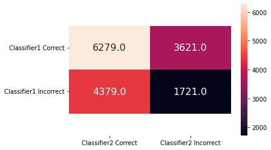

```python
import seaborn as sns

table = [[model1_tf[1]+model2_tf[1], model1_tf[1]+model2_tf[0]],
         [model1_tf[0]+model2_tf[1], model1_tf[0]+model2_tf[0]]]

table = pd.DataFrame(table, index=['Classifier1 Correct', 'Classifier1 Incorrect'],
                     columns=['Classifier2 Correct', 'Classifier2 Incorrect'])

sns.heatmap(table, annot=True, fmt=".1f", annot_kws={"size": 16})
plt.yticks(rotation=0)
b, t = plt.ylim()
b += 0.5
t -= 0.5
plt.ylim(b, t)
plt.show()
```

```python
# calculating the mcnemar test
from statsmodels.stats.contingency_tables import mcnemar

# calculate mcnemar test
result = mcnemar(table.values, exact=False, correction=True)

# summarize the finding
print('statistic=%.3f, p-value=%.3f' % (result.statistic, result.pvalue))

# interpret the p-value
alpha = 0.05
if result.pvalue > alpha:
    print('Same proportions of errors (fail to reject H0)')
else:
    print('Different proportions of errors (reject H0)')
```

```
statistic=71.631, p-value=0.000
Different proportions of errors (reject H0)
```

```python
model3_table = pd.DataFrame(yhat_gru, columns = ['y_pred'])
model3_table['y_true'] = y_test
model3_table['model3_tf'] = model3_table.y_true == model3_table.y_pred
model3_tf = model3_table.model3_tf.value_counts()
model3_tf
```

```
True     3347
False     653
Name: model3_tf, dtype: int64
```

```python
model4_table = pd.DataFrame(yhat_lstm2, columns = ['y_pred'])
model4_table['y_true'] = y_test
model4_table['model4_tf'] = model4_table.y_true == model4_table.y_pred
model4_tf = model4_table.model4_tf.value_counts()
model4_tf
```

```
True     3329
False     671
Name: model4_tf, dtype: int64
```

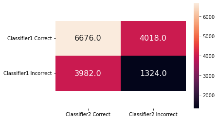

```python
import seaborn as sns

table = [[model3_tf[1]+model4_tf[1], model3_tf[1]+model4_tf[0]],
         [model3_tf[0]+model4_tf[1], model3_tf[0]+model4_tf[0]]]

table = pd.DataFrame(table, index=['Classifier1 Correct', 'Classifier1 Incorrect'],
                     columns=['Classifier2 Correct', 'Classifier2 Incorrect'])

sns.heatmap(table, annot=True, fmt=".1f", annot_kws={"size": 16})
plt.yticks(rotation=0)
b, t = plt.ylim()
b += 0.5
t -= 0.5
plt.ylim(b, t)
plt.show()
```

```python
# calculating the mcnemar test
from statsmodels.stats.contingency_tables import mcnemar

# calculate mcnemar test
result = mcnemar(table.values, exact=False, correction=True)

# summarize the finding
print('statistic=%.3f, p-value=%.3f' % (result.statistic, result.pvalue))

# interpret the p-value
alpha = 0.05
if result.pvalue > alpha:
    print('Same proportions of errors (fail to reject H0)')
else:
    print('Different proportions of errors (reject H0)')
```

```
statistic=0.153, p-value=0.696
Same proportions of errors (fail to reject H0)
```

I followed this webpage for McNemar’s Test :https://www.srose.biz/wp-content/uploads/2020/08/Comparing-Machine-Learning-Algorithms.html

#### Q7-Use dimensionality reduction (choose an appropriate method from this list: t-SNE, SVD, PCA, or UMAP) to visualize the word embeddings of a subset of words in your vocabulary that you expect to have an analogy that can be captured by the embedding. Try to interpret if an analogy exists, show the vectors that support/refute the analogy, and interpret your findings.

```python
word_index
```

[output not shown]

[output cut: 946 more lines]

[output not shown]

```python
# making the vocabulary dataframe
vocabulary = pd.DataFrame.from_dict(word_index,orient='index')
vocabulary.reset_index(level=0, inplace=True)
vocabulary = vocabulary.rename(columns={'index': 'words_', 0: 'count'})
vocabulary
```

|  | words_ | count |
| --- | --- | --- |
| 0 | the | 1 |
| 1 | to | 2 |
| 2 | is | 3 |
| 3 | a | 4 |
| 4 | why | 5 |
| ... | ... | ... |
| 23399 | kilogram | 23400 |
| 23400 | raid | 23401 |
| 23401 | redistribution | 23402 |
| 23402 | chores | 23403 |
| 23403 | psyops | 23404 |

23404 rows × 2 columns

```python
vocabulary.words_
```

```
0                   the
1                    to
2                    is
3                     a
4                   why
              ...
23399          kilogram
23400              raid
23401    redistribution
23402            chores
23403            psyops
Name: words_, Length: 23404, dtype: object
```

```python
# getting the embedding weights
emb_layer = gru2.layers[0]
weights = emb_layer.get_weights()[0]
weights= weights[1:]
weights
```

```
array([[ 0.418   ,  0.24968 , -0.41242 , ..., -0.18411 , -0.11514 ,
        -0.78581 ],
       [ 0.68047 , -0.039263,  0.30186 , ..., -0.073297, -0.064699,
        -0.26044 ],
       [ 0.6185  ,  0.64254 , -0.46552 , ..., -0.27557 ,  0.30899 ,
         0.48497 ],
       ...,
       [-0.74997 , -1.2323  , -0.48923 , ..., -0.20501 ,  1.3725  ,
        -0.38864 ],
       [ 0.23938 , -0.59103 , -0.86057 , ..., -0.30113 ,  0.18311 ,
         1.1629  ],
       [-0.59041 , -0.43978 , -0.1069  , ...,  1.3775  , -0.48701 ,
         1.2136  ]], dtype=float32)
```

```python
weights.shape
```

```
(23404, 50)
```

```python
#reduce the weights 50D into 2D using TSNE
from sklearn.manifold import TSNE
tsne = TSNE(n_components=2,perplexity=30)
data_2d = tsne.fit_transform(weights)
```

```python
data_2d
```

```
array([[  6.8786626, -34.29716  ],
       [ 12.708626 , -37.02682  ],
       [  8.345776 , -34.028522 ],
       ...,
       [ 41.67819  , -42.322006 ],
       [ 16.423925 ,  13.0820875],
       [  6.983145 ,  27.771782 ]], dtype=float32)
```

```python
#making the final dataframe for visualization
two_D_df = pd.DataFrame(data_2d)
two_D_df = pd.concat([two_D_df,vocabulary],axis=1)
two_D_df = two_D_df.rename(columns={0: '1D', 1: '2D'})
two_D_df=two_D_df.iloc[943:993,:]
two_D_df
```

|  | 1D | 2D | words_ | count |
| --- | --- | --- | --- | --- |
| 943 | -49.497402 | -16.744406 | syria | 944 |
| 944 | 3.781365 | -43.616894 | pm | 945 |
| 945 | 29.043617 | -22.255104 | please | 946 |
| 946 | -48.500946 | 28.303583 | dick | 947 |
| 947 | 36.285248 | -32.692249 | refuse | 948 |
| 948 | 37.984322 | 21.254034 | homosexuality | 949 |
| 949 | 12.691005 | -24.761341 | names | 950 |
| 950 | 10.777795 | -43.356388 | send | 951 |
| 951 | 46.959793 | -16.639072 | violent | 952 |
| 952 | 21.192484 | -32.026363 | quality | 953 |
| 953 | 47.195908 | -8.431143 | slavery | 954 |
| 954 | 9.089006 | -26.051146 | list | 955 |
| 955 | 8.312016 | -24.321676 | available | 956 |
| 956 | 8.779967 | -36.887215 | taken | 957 |
| 957 | -10.044930 | -40.856560 | rank | 958 |
| 958 | -9.813739 | -46.161568 | training | 959 |
| 959 | -31.251621 | -18.977480 | ancient | 960 |
| 960 | 7.968791 | -41.521877 | recent | 961 |
| 961 | -4.473006 | -20.078445 | hot | 962 |
| 962 | 22.815386 | -32.520954 | necessary | 963 |
| 963 | 28.220917 | -16.367094 | proud | 964 |
| 964 | -8.714443 | -4.978724 | clothes | 965 |
| 965 | -10.815909 | -50.177422 | educated | 966 |
| 966 | -7.428213 | 48.955669 | you're | 967 |
| 967 | 12.293333 | -37.790058 | return | 968 |
| 968 | 0.062728 | 9.277657 | animal | 969 |
| 969 | 27.964016 | -20.144299 | yourself | 970 |
| 970 | 17.172453 | -13.942643 | scientific | 971 |
| 971 | 8.036665 | -29.626732 | original | 972 |
| 972 | 17.337833 | -38.191326 | convert | 973 |
| 973 | 12.591669 | -38.990784 | tried | 974 |
| 974 | 2.991060 | -66.463707 | 13 | 975 |
| 975 | 19.031260 | -30.442221 | constantly | 976 |
| 976 | -1.655498 | 9.585046 | cat | 977 |
| 977 | 46.021317 | -30.848814 | court | 978 |
| 978 | 13.155914 | -28.525307 | generally | 979 |
| 979 | -22.341694 | -50.549183 | straight | 980 |
| 980 | 2.893361 | -28.678007 | lies | 981 |
| 981 | 50.757408 | -13.680219 | innocent | 982 |
| 982 | 3.074219 | -36.659077 | running | 983 |
| 983 | 1.090167 | -35.202034 | wing | 984 |
| 984 | 25.059975 | -46.216919 | offer | 985 |
| 985 | 1.550310 | -63.005310 | three | 986 |
| 986 | 22.964653 | -32.580254 | effective | 987 |
| 987 | -27.362209 | 10.589098 | g | 988 |
| 988 | 5.656566 | -56.676304 | minority | 989 |
| 989 | 16.103342 | -55.455418 | financial | 990 |
| 990 | -8.024721 | -38.413364 | wars | 991 |
| 991 | 10.220456 | -40.309372 | lead | 992 |
| 992 | 18.823492 | -22.622061 | nature | 993 |

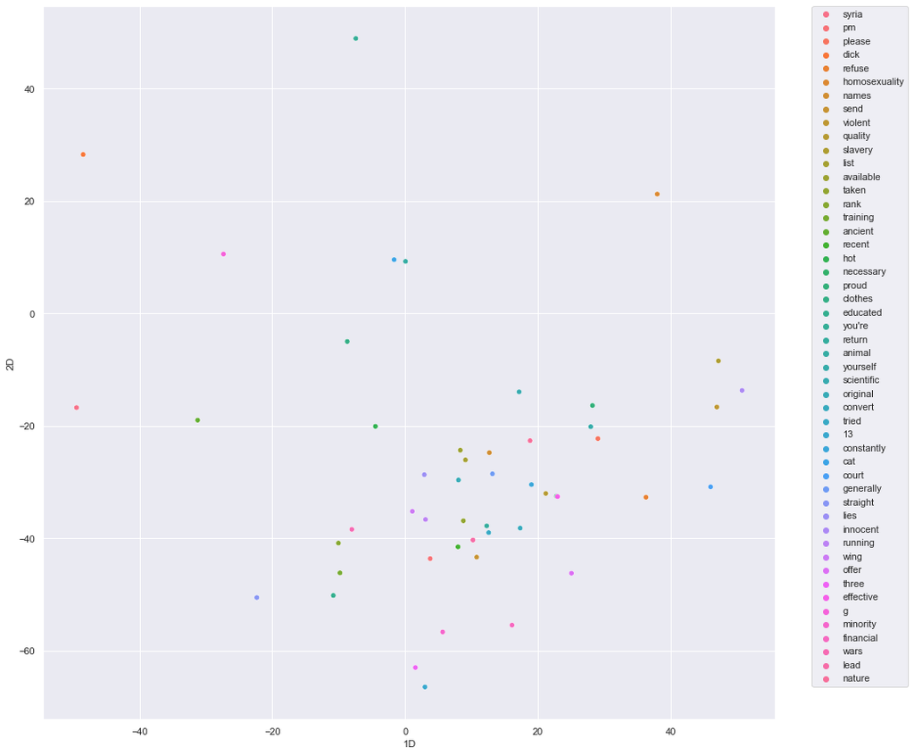

```python
#visualization the 50 subset of embedding in seaborn scatter plot
sns.set_style("whitegrid")
gfg = sns.set(rc = {'figure.figsize':(15,15)})
gfg = sns.scatterplot(data=two_D_df, x='1D', y='2D',hue="words_")
plt.legend(bbox_to_anchor=(1.05, 1), loc=2, borderaxespad=0.)
plt.setp(gfg.get_legend().get_texts(), fontsize='11')
plt.show()
```

In my interpretation, I need to select the positive(sincere) words and negative (Toxic words). If there is more toxic words that content should remove automatically. I can see in my graph left hand side top corner word(Orange colour) is "dick" and it is a toxic word which represent in diffrent place than others (x=-40). In the other hand, words like "Innocent, slavery, court" in the (X= +40) in the graph. other words are spreaded in the graph, and those are neutral and day to day words.

```python
two_D_df = pd.DataFrame(data_2d)
two_D_df = pd.concat([two_D_df,vocabulary],axis=1)
two_D_df = two_D_df.rename(columns={0: '1D', 1: '2D'})
two_D_df=two_D_df.iloc[946:947,:]
two_D_df
```

|  | 1D | 2D | words_ | count |
| --- | --- | --- | --- | --- |
| 946 | -48.500946 | 28.303583 | dick | 947 |

Above mentioned the coordinates of "dick" word.

```python
two_D_df = pd.DataFrame(data_2d)
two_D_df = pd.concat([two_D_df,vocabulary],axis=1)
two_D_df = two_D_df.rename(columns={0: '1D', 1: '2D'})
two_D_df=two_D_df.iloc[981:982,:]
two_D_df
```

|  | 1D | 2D | words_ | count |
| --- | --- | --- | --- | --- |
| 981 | 50.757408 | -13.680219 | innocent | 982 |

Above mentioned the coordinates of "innocent" word.